# Identier les facteurs latents en SHS avec R

Etape 2 : Réaliser la CFA

```r
### Attacher car R refuse les $
attach(dfz_2023_B)

model23 <- 'F1 =~ Superf + Pop
           F2 =~ indice_fecond + plus65 + RNB_hab'

library(lavaan)

fit23 <- cfa(model23, std.lv=T, estimator="MLR", data=dfz_2023_B)


effectsize::interpret(fit23)
```

```
    Name      Value Threshold Interpretation
1    GFI 0.96617198      0.95   satisfactory
2   AGFI 0.87314492      0.90           poor
3    NFI 0.95803658      0.90   satisfactory
4   NNFI 0.92359123      0.90   satisfactory
5    CFI 0.96943649      0.90   satisfactory
6  RMSEA 0.12442816      0.05           poor
7   SRMR 0.04451438      0.08   satisfactory
8    RFI 0.89509145      0.90           poor
9   PNFI 0.38321463      0.50           poor
10   IFI 0.97000943      0.90   satisfactory
```

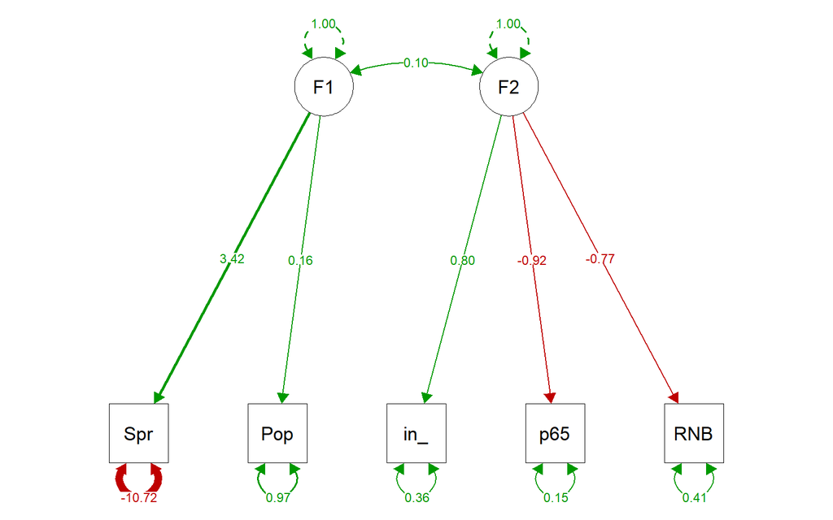

```r
semPlot::semPaths(fit23, "std",
             sizeMan = 8, sizeInt = 8, sizeLat = 8,
             edge.label.cex=0.8,
             fade=FALSE)
```

Les indices de la CFA sont satisfaisants (6 sur 10, et 2 sont proches des seuils), ce qui traduit une bonne adéquation du modèle à nos données. La structure testée en 2011 sur certains pays se retrouve bien en 2023. La distinction entre les pays étudiés se structure selon 2 facteurs : la superficie et la population d’une part et l’indice de fécondité et la part des plus de 65 ans dans la population ainsi que le RNB. Il est à noter que ce deuxième facteur rassemble des indices contraires, c’est-à-dire que les pays ayant un fort taux de fécondité sont aussi ceux qui ont une part des plus de 65 ans dans leur population faible et un RNB bas.

Si les résultats ne sont pas révolutionnaires et que le nettoyage préliminaire ne permet pas de leur attribuer une portée générale, nous avons toutefois pu observer que le duo analyse factorielle exploratoire et analyse factorielle confirmatoire permet de rendre compte de la stabilité d’une structure d’un modèle théorique dans le temps.

## 6.3 Est-ce que je mesure bien ce que je pense mesurer : l’exemple des tests psychométriques en Psychologie

En Psychologie, un exemple classique de l’utilisation des couples AFE/AFC concerne la validation des tests psychométriques. Afin de réaliser des tests standardisés pour évaluer des processus psychologiques, les psychologues ont recours à ce couple d’analyses factorielles, en réalisant une analyse factorielle exploratoire sur un premier échantillon et une analyse factorielle confirmatoire sur un second échantillon (ayant tous 2 les mêmes caractéristiques).

Nous allons illustrer notre démarche avec l’utilisation d’un outil psychométrique le *Revised Paranormal Beliefs Scale - RPBS* à partir des données issues de l’article de Pennycook G, et al. 2020.

Le RPBS est un outil psychométrique utilisé afin de mesurer la croyance des individus dans des phénomènes paranormaux. Habituellement composé de 26 items répartis en 7 facteurs, la version utilisée dans l’article présenté se décompose en 22 variables répartis en 6 facteurs latents. Le facteur correspondant aux croyances religieuses traditionnelles ayant été sorti de l’outil, avec les variables qui le composent.

Les variables de notre base de données se répartissent comme ceci, un exemple d’intitulé de variable est présenté entre parenthèses pour chaque facteur :

- Phénomènes parapsychologiques (*“Lire dans les pensées est possible”*) : PB_1, PB_7, PB_13, PB_19
- Sorcellerie (*“Les sorciers existent”*) : PB_2, PB_8, PB_14, PB_20
- Superstition (*“Les chats noirs portent malheur”*) : PB_3, PB_9, PB_15
- Spiritualité (*“Il est possible de communiquer avec les morts”*) : PB_4, PB_10, PB_16, PB_21
- Formes de vie extraordinaires (*“Le monstre du Loch Ness existe”*) : PB_5, PB_11, PB_17
- Précognition (*“L’astrologie est une voie pertinente pour prédire le futur”*) : PB_6, PB_12, PB_18, PB_22

### 6.3.1 Préparation du jeu de données

Charger le jeu de données et standardiser les variables d’intérêt.

```r
# Chargement des données de base

library(here)
csv_path <- here("data", "Study3_RPB.csv")

RPB <- read.csv2(csv_path, row.names=1)

# Sélection des 22 items :

RPBp<-subset(RPB, select = c("PB_1", "PB_2", "PB_3", "PB_4", "PB_5", "PB_6", "PB_7" ,"PB_8", "PB_9", "PB_10", "PB_11", "PB_12", "PB_13", "PB_14", "PB_15", "PB_16", "PB_17", "PB_18", "PB_19", "PB_20", "PB_21", "PB_22"))

# Conversion des variables en format numérique (car elles sont considérées comme catégorielles)
RPBpn <- as.data.frame(lapply(RPBp, as.numeric))
```

Nous allons débuter par partitionner notre jeu de données pour ne pas exécuter l’AFE et l’AFC sur le même échantillon.

```r
## En premier lien le partitionnement des data
partitions <- datawizard::data_partition(RPBpn, proportion = 0.5, seed = 424)
training <- partitions$p_0.5
test <- partitions$test

training$.row_id <- NULL
test$.row_id <- NULL

### Centrer et réduire les variables de nos 2 jeux de données
trainingz <-  na.omit(data.frame(scale(training, center=T, scale=T)))
testz <-  na.omit(data.frame(scale(test, center=T, scale=T)))
```

Nous avons vérifié les statistiques descriptives sur notre jeu de données. Nous ne les présentons pas dans cet exemple pour plus de lisibilité. Il est toutefois à noter qu’il n’y a pas de différence statistiquement significative des scores obtenus sur chaque variable pour nos deux échantillons *training* et *test*.

### 6.3.2 Nettoyage des données

**Etape 1 : les outliers**

Identification et suppression des outliers sur nos deux jeux de données test et training.

**Multioutliers base training**

```r
# Multioutliers base training
#MCD avec le package rrcov
library(rrcov)
# 1- calcul de la distance MCD
mcd_RPBS1 <- CovMcd(trainingz, alpha=0.75)
# L'objet `mcd_result` contient toutes les informations concernant le calcul sur notre base de données
# 2- visualisation des outliers
#plot(mcd_RPBS1, which="all")

# suppression des valeurs manquantes
trainingzout<-cbind(trainingz, mcd_RPBS1$wt)
trainingzoutp<-subset(trainingzout, mcd_RPBS1$wt %in% c(0,1))

# fusion de la base initiale et des distances de mahalanobis robustes
trainingzmah<-cbind(trainingzoutp, mcd_RPBS1$raw.mah)

# 3- suppression des outliers
trainingzp<-subset(trainingzmah, trainingzmah$`mcd_RPBS1$raw.mah`< 100)

# On recalcule la distance de mahalanobis robuste sur notre base de données sans les premiers outliers, pour voir s'il en reste
trainingz_B<-subset(trainingzp, select = -c(`mcd_RPBS1$raw.mah`, `mcd_RPBS1$wt`))
# 1- calcul de la distance MCD
mcd_RPBS1_2 <- CovMcd(trainingz_B, alpha=0.75)
# L'objet `mcd_result` contient toutes les informations concernant le calcul sur notre base de données
# 2- visualisation des outliers
#plot(mcd_RPBS1_2, which="all")
```

**Multioutliers base test**

```r
# Multioutliers base test
#MCD avec le package rrcov

# 1- calcul de la distance MCD
mcd_RPBS2 <- CovMcd(testz, alpha=0.75)
# L'objet `mcd_result` contient toutes les informations concernant le calcul sur notre base de données
# 2- visualisation des outliers
#plot(mcd_RPBS2, which="all")

# suppression des valeurs manquantes
testzout<-cbind(testz, mcd_RPBS2$wt)
testzoutp<-subset(testzout, mcd_RPBS2$wt %in% c(0,1))

# fusion de la base initiale et des distances de mahalanobis robustes
testzmah<-cbind(testzoutp, mcd_RPBS2$raw.mah)

# 3- suppression des outliers
testzp<-subset(testzmah, testzmah$`mcd_RPBS2$raw.mah`< 100)

# On recalcule la distance de mahalanobis robuste sur notre base de données sans les premiers outliers, pour voir s'il en reste
testz_B<-subset(testzp, select = -c(`mcd_RPBS2$raw.mah`, `mcd_RPBS2$wt`))
# 1- calcul de la distance MCD
mcd_RPBS2_2 <- CovMcd(testz_B, alpha=0.75)
# L'objet `mcd_result` contient toutes les informations concernant le calcul sur notre base de données
# 2- visualisation des outliers
#plot(mcd_RPBS2_2, which="all")

# Aucun sujet ne se détache du groupe avec le calcul de la distance de Mahalanobis robuste dans chacune des 2 bases de données testées après les premières suppression. Nous ne supprimons pas de valeurs supplémentaires.
```

Notre jeu de données **training** comportait 6 outliers et le jeu de données **test** en comportait 10. Nous les avons donc supprimés. Tout comme l’exemple précédent, les outliers entrainant le plus de biais ont été supprimés de notre jeu de données. Le seuil de 100 a également été retenu suite à différentes itérations du calcul de la distance de Mahalanobis robuste.

**Etape 2 : la multicolinéarité**

```r
# corrélations

cor <- correlation(trainingz_B, method = "spearman")

cor %>%
  summary(redundant = FALSE)
```

```
# Correlation Matrix (spearman-method)

Parameter |   PB_22 |   PB_21 |   PB_20 |   PB_19 |   PB_18 |   PB_17 |   PB_16 |   PB_15 |   PB_14 |   PB_13 |   PB_12 |   PB_11 |   PB_10 |    PB_9 |    PB_8 |    PB_7 |    PB_6 |    PB_5 |    PB_4 |    PB_3 |    PB_2
---------------------------------------------------------------------------------------------------------------------------------------------------------------------------------------------------------------------------
PB_1      | 0.59*** | 0.55*** | 0.46*** | 0.63*** | 0.61*** | 0.38*** | 0.44*** | 0.40*** | 0.64*** | 0.81*** | 0.48*** | 0.49*** | 0.61*** | 0.41*** | 0.47*** | 0.76*** | 0.51*** | 0.55*** | 0.62*** | 0.35*** | 0.54***
PB_2      | 0.52*** | 0.43*** | 0.72*** | 0.43*** | 0.44*** | 0.28*** | 0.32*** | 0.23*** | 0.56*** | 0.53*** | 0.32*** | 0.35*** | 0.48*** | 0.21*** | 0.68*** | 0.53*** | 0.35*** | 0.34*** | 0.46*** |   0.14* |
PB_3      |  0.19** | 0.28*** |   0.12* | 0.32*** | 0.29*** |   0.14* | 0.30*** | 0.66*** | 0.42*** | 0.34*** | 0.49*** | 0.28*** | 0.29*** | 0.69*** |    0.09 | 0.26*** | 0.49*** | 0.34*** | 0.21*** |         |
PB_4      | 0.64*** | 0.64*** | 0.43*** | 0.57*** | 0.57*** | 0.52*** | 0.56*** | 0.30*** | 0.52*** | 0.66*** | 0.42*** | 0.41*** | 0.72*** | 0.32*** | 0.37*** | 0.59*** | 0.49*** | 0.43*** |         |         |
PB_5      | 0.33*** | 0.36*** | 0.33*** | 0.49*** | 0.35*** | 0.32*** | 0.31*** | 0.37*** | 0.45*** | 0.53*** | 0.39*** | 0.62*** | 0.35*** | 0.42*** | 0.36*** | 0.46*** | 0.44*** |         |         |         |
PB_6      | 0.48*** | 0.55*** | 0.37*** | 0.53*** | 0.61*** | 0.40*** | 0.56*** | 0.56*** | 0.55*** | 0.54*** | 0.81*** | 0.44*** | 0.51*** | 0.59*** | 0.29*** | 0.50*** |         |         |         |         |
PB_7      | 0.59*** | 0.52*** | 0.50*** | 0.59*** | 0.59*** | 0.43*** | 0.47*** | 0.32*** | 0.59*** | 0.72*** | 0.43*** | 0.38*** | 0.58*** | 0.35*** | 0.47*** |         |         |         |         |         |
PB_8      | 0.44*** | 0.35*** | 0.74*** | 0.40*** | 0.37*** | 0.22*** | 0.23*** |   0.15* | 0.53*** | 0.45*** | 0.25*** | 0.35*** | 0.41*** |   0.15* |         |         |         |         |         |         |
PB_9      | 0.22*** | 0.38*** |  0.18** | 0.39*** | 0.38*** |  0.18** | 0.37*** | 0.75*** | 0.49*** | 0.39*** | 0.64*** | 0.34*** | 0.34*** |         |         |         |         |         |         |         |
PB_10     | 0.60*** | 0.59*** | 0.41*** | 0.56*** | 0.58*** | 0.40*** | 0.54*** | 0.33*** | 0.53*** | 0.61*** | 0.47*** | 0.40*** |         |         |         |         |         |         |         |         |
PB_11     | 0.35*** | 0.37*** | 0.36*** | 0.45*** | 0.31*** | 0.39*** | 0.30*** | 0.32*** | 0.43*** | 0.45*** | 0.45*** |         |         |         |         |         |         |         |         |         |
PB_12     | 0.41*** | 0.44*** | 0.30*** | 0.48*** | 0.56*** | 0.29*** | 0.48*** | 0.57*** | 0.51*** | 0.52*** |         |         |         |         |         |         |         |         |         |         |
PB_13     | 0.60*** | 0.55*** | 0.47*** | 0.67*** | 0.55*** | 0.39*** | 0.49*** | 0.39*** | 0.65*** |         |         |         |         |         |         |         |         |         |         |         |
PB_14     | 0.50*** | 0.52*** | 0.54*** | 0.61*** | 0.50*** | 0.32*** | 0.42*** | 0.44*** |         |         |         |         |         |         |         |         |         |         |         |         |
PB_15     |  0.19** | 0.31*** |  0.18** | 0.35*** | 0.33*** |   0.14* | 0.36*** |         |         |         |         |         |         |         |         |         |         |         |         |         |
PB_16     | 0.52*** | 0.61*** | 0.29*** | 0.50*** | 0.47*** | 0.47*** |         |         |         |         |         |         |         |         |         |         |         |         |         |         |
PB_17     | 0.46*** | 0.43*** | 0.32*** | 0.43*** | 0.42*** |         |         |         |         |         |         |         |         |         |         |         |         |         |         |         |
PB_18     | 0.70*** | 0.61*** | 0.45*** | 0.63*** |         |         |         |         |         |         |         |         |         |         |         |         |         |         |         |         |
PB_19     | 0.61*** | 0.53*** | 0.43*** |         |         |         |         |         |         |         |         |         |         |         |         |         |         |         |         |         |
PB_20     | 0.52*** | 0.43*** |         |         |         |         |         |         |         |         |         |         |         |         |         |         |         |         |         |         |
PB_21     | 0.62*** |         |         |         |         |         |         |         |         |         |         |         |         |         |         |         |         |         |         |         |

p-value adjustment method: Holm (1979)
```

```r
cor <- correlation(testz_B, method = "spearman")

cor %>%
  summary(redundant = FALSE)
```

```
# Correlation Matrix (spearman-method)

Parameter |   PB_22 |   PB_21 |   PB_20 |   PB_19 |   PB_18 |   PB_17 |   PB_16 |   PB_15 |   PB_14 |   PB_13 |   PB_12 |   PB_11 |   PB_10 |    PB_9 |    PB_8 |    PB_7 |    PB_6 |    PB_5 |    PB_4 |    PB_3 |    PB_2
---------------------------------------------------------------------------------------------------------------------------------------------------------------------------------------------------------------------------
PB_1      | 0.49*** | 0.55*** | 0.46*** | 0.61*** | 0.57*** | 0.38*** | 0.51*** | 0.37*** | 0.61*** | 0.76*** | 0.50*** | 0.51*** | 0.60*** | 0.46*** | 0.41*** | 0.77*** | 0.52*** | 0.53*** | 0.59*** | 0.38*** | 0.54***
PB_2      | 0.53*** | 0.57*** | 0.71*** | 0.56*** | 0.51*** | 0.45*** | 0.51*** | 0.35*** | 0.71*** | 0.58*** | 0.49*** | 0.44*** | 0.56*** | 0.39*** | 0.72*** | 0.58*** | 0.51*** | 0.46*** | 0.60*** | 0.28*** |
PB_3      | 0.22*** | 0.31*** | 0.23*** | 0.34*** | 0.37*** | 0.17*** | 0.30*** | 0.66*** | 0.42*** | 0.37*** | 0.54*** | 0.36*** | 0.30*** | 0.66*** | 0.20*** | 0.36*** | 0.46*** | 0.43*** | 0.35*** |         |
PB_4      | 0.58*** | 0.62*** | 0.51*** | 0.59*** | 0.58*** | 0.54*** | 0.63*** | 0.35*** | 0.61*** | 0.66*** | 0.46*** | 0.45*** | 0.78*** | 0.38*** | 0.47*** | 0.63*** | 0.52*** | 0.45*** |         |         |
PB_5      | 0.39*** | 0.45*** | 0.39*** | 0.47*** | 0.46*** | 0.39*** | 0.40*** | 0.41*** | 0.49*** | 0.56*** | 0.46*** | 0.68*** | 0.42*** | 0.45*** | 0.40*** | 0.56*** | 0.46*** |         |         |         |
PB_6      | 0.46*** | 0.59*** | 0.45*** | 0.53*** | 0.57*** | 0.38*** | 0.54*** | 0.49*** | 0.58*** | 0.57*** | 0.75*** | 0.43*** | 0.55*** | 0.54*** | 0.42*** | 0.54*** |         |         |         |         |
PB_7      | 0.55*** | 0.57*** | 0.49*** | 0.66*** | 0.61*** | 0.44*** | 0.50*** | 0.41*** | 0.65*** | 0.79*** | 0.53*** | 0.55*** | 0.62*** | 0.47*** | 0.43*** |         |         |         |         |         |
PB_8      | 0.53*** | 0.49*** | 0.73*** | 0.47*** | 0.46*** | 0.36*** | 0.46*** | 0.24*** | 0.58*** | 0.45*** | 0.35*** | 0.33*** | 0.42*** | 0.31*** |         |         |         |         |         |         |
PB_9      | 0.30*** | 0.42*** | 0.35*** | 0.41*** | 0.44*** | 0.21*** | 0.44*** | 0.64*** | 0.59*** | 0.47*** | 0.62*** | 0.42*** | 0.37*** |         |         |         |         |         |         |         |
PB_10     | 0.53*** | 0.60*** | 0.46*** | 0.60*** | 0.56*** | 0.53*** | 0.61*** | 0.33*** | 0.61*** | 0.66*** | 0.51*** | 0.42*** |         |         |         |         |         |         |         |         |
PB_11     | 0.36*** | 0.38*** | 0.36*** | 0.44*** | 0.44*** | 0.44*** | 0.33*** | 0.35*** | 0.56*** | 0.51*** | 0.45*** |         |         |         |         |         |         |         |         |         |
PB_12     | 0.43*** | 0.51*** | 0.41*** | 0.53*** | 0.57*** | 0.32*** | 0.47*** | 0.57*** | 0.59*** | 0.53*** |         |         |         |         |         |         |         |         |         |         |
PB_13     | 0.53*** | 0.59*** | 0.48*** | 0.69*** | 0.58*** | 0.48*** | 0.52*** | 0.39*** | 0.65*** |         |         |         |         |         |         |         |         |         |         |         |
PB_14     | 0.50*** | 0.57*** | 0.62*** | 0.58*** | 0.57*** | 0.45*** | 0.53*** | 0.38*** |         |         |         |         |         |         |         |         |         |         |         |         |
PB_15     | 0.28*** | 0.34*** | 0.26*** | 0.38*** | 0.37*** | 0.21*** | 0.32*** |         |         |         |         |         |         |         |         |         |         |         |         |         |
PB_16     | 0.55*** | 0.67*** | 0.43*** | 0.53*** | 0.56*** | 0.44*** |         |         |         |         |         |         |         |         |         |         |         |         |         |         |
PB_17     | 0.43*** | 0.43*** | 0.37*** | 0.46*** | 0.45*** |         |         |         |         |         |         |         |         |         |         |         |         |         |         |         |
PB_18     | 0.68*** | 0.59*** | 0.51*** | 0.59*** |         |         |         |         |         |         |         |         |         |         |         |         |         |         |         |         |
PB_19     | 0.60*** | 0.58*** | 0.46*** |         |         |         |         |         |         |         |         |         |         |         |         |         |         |         |         |         |
PB_20     | 0.55*** | 0.54*** |         |         |         |         |         |         |         |         |         |         |         |         |         |         |         |         |         |         |
PB_21     | 0.58*** |         |         |         |         |         |         |         |         |         |         |         |         |         |         |         |         |         |         |         |

p-value adjustment method: Holm (1979)
```

```r
### gestion multicolinéarité

vifstep(trainingz_B, method = "spearman")
```

```
No variable from the 22 input variables has collinearity problem.

The linear correlation coefficients ranges between:
min correlation ( PB_8 ~ PB_3 ):  0.09464123
max correlation ( PB_13 ~ PB_1 ):  0.8141815

---------- VIFs of the remained variables --------
   Variables      VIF
1       PB_1 4.560558
2       PB_2 2.734096
3       PB_3 2.208149
4       PB_4 3.333450
5       PB_5 2.135252
6       PB_6 3.720740
7       PB_7 3.043448
8       PB_8 2.750028
9       PB_9 2.994793
10     PB_10 2.853347
11     PB_11 2.108972
12     PB_12 3.566169
13     PB_13 4.093647
14     PB_14 2.697757
15     PB_15 2.422444
16     PB_16 2.160766
17     PB_17 1.693175
18     PB_18 3.246472
19     PB_19 2.629454
20     PB_20 3.221506
21     PB_21 2.485992
22     PB_22 3.108305
```

```r
vifstep(testz_B, method = "spearman")
```

```
No variable from the 22 input variables has collinearity problem.

The linear correlation coefficients ranges between:
min correlation ( PB_17 ~ PB_3 ):  0.1696088
max correlation ( PB_13 ~ PB_7 ):  0.7927911

---------- VIFs of the remained variables --------
   Variables      VIF
1       PB_1 3.249071
2       PB_2 3.455955
3       PB_3 2.302907
4       PB_4 3.436888
5       PB_5 2.232409
6       PB_6 2.764499
7       PB_7 3.908038
8       PB_8 2.816476
9       PB_9 2.757670
10     PB_10 3.227192
11     PB_11 2.229256
12     PB_12 2.835638
13     PB_13 4.070802
14     PB_14 3.390919
15     PB_15 2.227571
16     PB_16 2.544398
17     PB_17 1.714579
18     PB_18 2.745161
19     PB_19 2.647356
20     PB_20 3.014730
21     PB_21 2.686851
22     PB_22 2.546744
```

Aucun problème de multicolinéarité n’a été détecté, tous nos VIF sont inférieurs à 5 pour nos 2 jeux de données.

Nous allons pouvoir procéder aux étapes suivantes.

### 6.3.3 Réalisons l’AFE

Nos données sont-elles factorisables ? - KMO & Bartlett

```r
#Avec psych
## KMO
KMO(trainingz_B)
```

```
Kaiser-Meyer-Olkin factor adequacy
Call: KMO(r = trainingz_B)
Overall MSA =  0.94
MSA for each item =
 PB_1  PB_2  PB_3  PB_4  PB_5  PB_6  PB_7  PB_8  PB_9 PB_10 PB_11 PB_12 PB_13
 0.93  0.95  0.91  0.94  0.93  0.93  0.97  0.92  0.90  0.95  0.90  0.91  0.95
PB_14 PB_15 PB_16 PB_17 PB_18 PB_19 PB_20 PB_21 PB_22
 0.97  0.92  0.95  0.94  0.93  0.97  0.91  0.96  0.96
```

```r
## Test de sphéricité
cortest.bartlett(trainingz_B, n=370)
```

```
$chisq
[1] 5995.078

$p.value
[1] 0

$df
[1] 231
```

```r
# Avec performance
performance::check_factorstructure(trainingz_B)
```

```
# Is the data suitable for Factor Analysis?


  - Sphericity: Bartlett's test of sphericity suggests that there is sufficient significant correlation in the data for factor analysis (Chisq(231) = 5995.08, p < .001).
  - KMO: The Kaiser, Meyer, Olkin (KMO) overall measure of sampling adequacy suggests that data seems appropriate for factor analysis (KMO = 0.94). The individual KMO scores are: PB_1 (0.93), PB_2 (0.95), PB_3 (0.91), PB_4 (0.94), PB_5 (0.93), PB_6 (0.93), PB_7 (0.97), PB_8 (0.92), PB_9 (0.90), PB_1…
```

Les indices de sphéricité et de KMO (merveilleux) indiquent que nos données sont factorisables.

Procédons à l’AFE

```r
# Nombre de facteurs à conserver
n <- n_factors(trainingz_B)
n
```

```
# Method Agreement Procedure:

The choice of 4 dimensions is supported by 5 (26.32%) methods out of 19 (Bentler, beta, Optimal coordinates, Parallel analysis, Kaiser criterion).
```

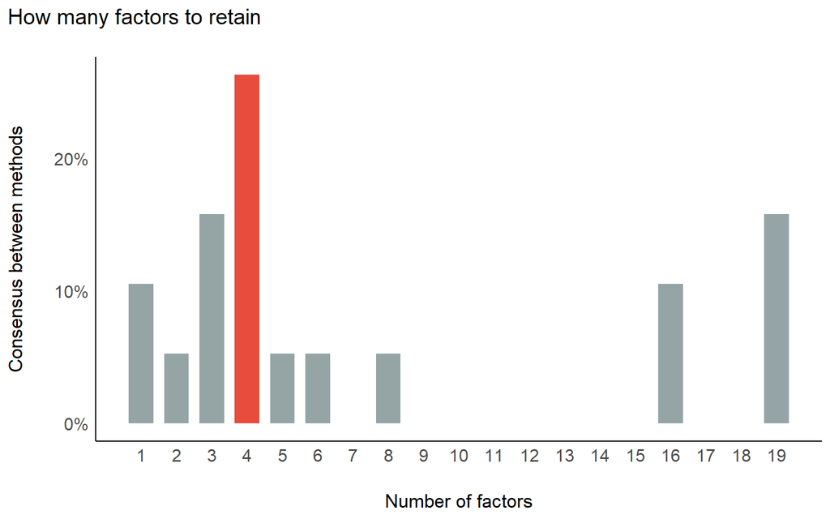

```r
library(see)
plot(n) + theme_modern()
```

```r
#SCREE_PLOT(trainingz_B, corkind="spearman", verbose=T)

AFERP<-lavaan::efa(trainingz_B, nfactors = 4, estimator = "MLR")
AFERP
```

```
          f1      f2      f3      f4
PB_1   0.936*
PB_2                   0.785*
PB_3       .   0.704*
PB_4   0.307                   0.640*
PB_5   0.523*      .*      .
PB_6           0.549*          0.536*
PB_7   0.617*              .       .
PB_8                   0.952*      .
PB_9       .   0.797*
PB_10      .                   0.563*
PB_11  0.316       .*      .
PB_12          0.610*          0.420*
PB_13  0.774*                      .
PB_14  0.355*      .*  0.367*
PB_15      .   0.730*
PB_16              .       .   0.748*
PB_17                          0.584*
PB_18      .       .           0.640*
PB_19  0.389*      .           0.371*
PB_20      .           0.991*
PB_21              .           0.703*
PB_22      .                   0.690*
```

### 6.3.4 Calcul de l’analyse factorielle confirmatoire sur la base test

Vérifions si cette structure en 4 facteurs se retrouve sur notre second jeu de données.

**1 - Procédons à l’analyse factorielle confirmatoire**

```r
library(lavaan)

attach(testz_B)

model <- 'F1 =~ PB_1 + PB_5 + PB_7 + PB_11 + PB_13 + PB_19
          F2 =~ PB_3 + PB_9 + PB_12 + PB_15
          F3 =~ PB_2 + PB_8 + PB_14 + PB_20
          F4 =~ PB_4 + PB_6 + PB_10 + PB_16 + PB_17 + PB_18 + PB_21 + PB_22'

fit2 <- cfa (model, std.lv=T, estimator="MLR", data=testz_B)
```

**2- Vérification de l’ajustement du modèle à nos données**

```r
## Résultat des indices

effectsize::interpret(fit2)
```

```
    Name      Value Threshold Interpretation
1    GFI 0.83347230      0.95           poor
2   AGFI 0.79245562      0.90           poor
3    NFI 0.86993845      0.90           poor
4   NNFI 0.88421239      0.90           poor
5    CFI 0.89824725      0.90           poor
6  RMSEA 0.09048906      0.05           poor
7   SRMR 0.06733462      0.08   satisfactory
8    RFI 0.85199893      0.90           poor
9   PNFI 0.76449137      0.50   satisfactory
10   IFI 0.89871145      0.90           poor
```

```r
## Saturations standardisées

# resid(fit2,type="standardized")
```

**4- Observation graphique de la structure obtenue**

[figure not shown]

```r
# On peut également représenter ce modèle :

semPlot::semPaths(fit2, "std",
             sizeMan = 8, sizeInt = 8, sizeLat = 8,
             edge.label.cex=0.8,
             fade=FALSE)
```

L’article décrit une échelle en 22 items répartis en 6 catégories de croyances aux phénomènes paranormaux, mais nous retrouvons une structure en 4 facteurs avec les mêmes items sur les mêmes données. Ceci peut être du a plusieurs éléments. Nous n’avons pas d’indication sur le traitement des valeurs extrêmes de la part des auteurs de l’article. De plus, nous n’avons pas d’éléments nous permettant d’affirmer qu’ils ont effectivement partitionné leur jeu de données avant de procéder à leurs analyses factorielles.

Un autre point à souligner, et pas des moindres, les auteurs n’ont très certainement pas réalisé d’analyse factorielle exploratoire. En effet, à partir du moment où un test psychométrique est validé, c’est-à-dire qu’il a déjà été éprouvé par le couple AFE/AFC sur un jeu de données assez conséquent, avec une population ayant les mêmes caractéristiques, il n’est pas nécessaire de remettre en cause la structure du test et nous pouvons directement procéder à une analyse factorielle confirmatoire, afin de vérifier si le modèle alors pré-établi par d’autres s’ajuste à nos données. Ceci est conseillé afin de ne pas multiplier les tests statistiques et entraîner une inflation des résultats faussements positifs (encore appelés erreur de type II).

La structure obtenue en 4 facteurs reste cohérente avec la proposition de départ en 6 facteurs. Certains regroupements restent inchangés, d’autres voient quelques modifications (2 items sont majoritairement reliés à un autre facteur latent que celui proposé dans la structure initiale), mais la structure obtenue a du sens et peut tout-à-fait servir de base de discussion à la construction d’outils psychométriques sur le sujet. Pour information, avec notre nouvelle structure nous obtenons la répartition suivante (en anglais) :

- F1 (Phénomènes parapsychologiques / Fomres de vie extraordinaires): 1. Some individuals are able to levitate (lift) objects through mental forces. ; 5. The abominable snowman of Tibet exists. ; 7. Psychokinesis, the movement of objects through psychic powers, does exist. ; 11. The Loch Ness monster of Scotland exists. ; 13. A person’s thoughts can influence the movement of a physical object. ; 19. Mind reading is not possible
- F2 (Superstition + item 12 (qui était dans la structure initiale relié majoritairement au facteur “Précognition”)) : 3. Black cats can bring bad luck. ; 9. If you break a mirror, you will have bad luck. ; 12. The horoscope accurately tells a person’s future. ;  
  15. The number “13” is unlucky.
- F3 (Sorcellerie): 2. Black magic really exists. ; 8. Witches do exist. ; 14. Through the use of formulas and incantations, it is possible to cast spells on persons. ; 20. There are actual cases of witchcraft.
- F4 (Spiritualité / Précognition - item12 + item17 (qui était dans la struture initiale majoritairement relié au facteur latent “Formes de vies extraordinaires”)): 4. Your mind or soul can leave your body and travel (astral projection). ; 6. Astrology is a way to accurately predict the future.; 10. During altered states, such as sleep or trances, the spirit can leave the body.;  
  16. Reincarnation does occur. ; 17. There is life on other planets. ; 18. Some psychics can accurately predict the future.; 21. It is possible to communicate with the dead. ; 22. Some people have an unexplained ability to predict the future.

# Conclusion

Nous avons ainsi présenté pas à pas trois exemples différents d’utilisation de l’AFE et en suivant de la CFA. L’idée était de présenter une méthode ancienne mais peu utilisée en dehors de la Psychologie. Il ne s’agit pas de remplacer l’ACP mais de proposer une alternative, et surtout de proposer aux usagers de faire un choix conscient sur la méthode plutôt que de répondre à une habitude disciplinaire.

Ainsi, si vous souhaitez explorer vos données et identifier des facteurs latents corrélés (ou non) afin de faire émerger une structure synthétique, voir si la structure observée est cohérente avec un modèle théorique, ou encore si cette structure observée est stable dans le temps, alors l’utilisation du couple entre AFE/CFA est tout-à-fait pertinente.

# Bibliographie

- Bartlett, M.S. (1937) Properties of Sufficiency and Statistical Test. Proceedings of the Royal Society A, 160, 268-282. https://doi.org/10.1098/rspa.1937.0109

- Benzecri J.-P. (1973), L’analyse des données, Paris, Dunod, vol. 2 : Correspondances

- Farrar, D. E., & Glauber, R. R. (1967). Multicollinearity in Regression Analysis: The Problem Revisited. The Review of Economics and Statistics, 49(1), 92–107. https://doi.org/10.2307/1937887.

- Flora, D. B., & Flake, J. K. (2017), The purpose and practice of exploratory and confirmatory factor analysis in psychological research: Decisions for scale development and validation. Canadian Journal of Behavioural Science / Revue canadienne des sciences du comportement, 49(2), 78–88. https://doi.org/10.1037/cbs0000069

- Gnanadesikan, R., & Kettenring, J. R. (1972), Robust Estimates, Residuals, and Outlier Detection with Multiresponse Data. Biometrics, 28(1), 81–124. https://doi.org/10.2307/2528963

- Hooper, D., Coughlan, J., & Mullen, M. R. (2008), Structural Equation Modelling: Guidelines for Determining Model Fit. The Electronic Journal of Business Research Methods, 6, 53-60.

- Kaiser, H.F. (1974) An index of factorial simplicity. Psychometrika 39, 31–36. https://doi.org/10.1007/BF02291575

- Kyriazos, T. and Poga, M. (2023) Dealing with Multicollinearity in Factor Analysis: The Problem, Detections, and Solutions. Open Journal of Statistics, 13, 404-424. doi: 10.4236/ojs.2023.133020

- Kyriazos, T. and Poga-Kyriazou, M. (2023) Applied Psychometrics: Estimator Considerations in Commonly Encountered Conditions in CFA, SEM, and EFA Practice. Psychology, 14, 799-828. doi: https://doi.org/10.4236/psych.2023.145043

- Leys, C., Klein, O., Dominicy, Y., and Ley., C., 2018, “Detecting Multivariate Outliers: Use a Robust Variant of the Mahalanobis Distance.” Journal of Experimental Social Psychology 74: 150–56. https://doi.org/10.1016/j.jesp.2017.09.011

- Mahalanobis, P., C., 1936, « On the generalised distance in statistics », Proceedings of the National Institute of Sciences of India, vol. 2, no 1, 1936, p. 49–55

- Makowski, (2018). The psycho Package: an Efficient and Publishing-Oriented Workflow for Psychological Science. Journal of Open Source Software, 3(22), 470. https://doi.org/10.21105/joss.00470

- Pages, J-P., et al., (1979), Analyse factorielle : Un peu d’histoire et de géométrie, Revue de statistiques appliquée, tome 27, n°1, p.5-28.

- Pearson F.R.S., K. (1901) LIII. On lines and planes of closest fit to systems of points in space, The London, Edinburgh, and Dublin Philosophical Magazine and Journal of Science, 2:11, 559-572, DOI: 10.1080/14786440109462720

- Pennycook G, Cheyne JA, Koehler DJ, Fugelsang JA, 2020, On the belief that beliefs should change according to evidence: Implications for conspiratorial, moral, paranormal, political, religious, and science beliefs. Judgment and Decision Making. 2020;15(4):476-498. doi:[10.1017/S1930297500007439](https://doi.org/10.1017/S1930297500007439)

- Spearman, C. (1904). The Proof and Measurement of Association between Two Things. The American Journal of Psychology, 15(1), 72–101. https://doi.org/10.2307/1412159

- Tabachnick, B., & Fidell, L., (2014), Using Multivariate Statistics (6th ed.). Harlow: Pearson Education

- Van Laar, S., & Braeken, J., 2021, Understanding the Comparative Fit Index : It’s All About Base !, Practical Assessment, Reasearch & Evaluation, Vol 26, N°26

- Yong, A. G., & Pearce, S. (2013) A Beginner’s Guide to Factor Analysis: Focusing on Exploratory Factor Analysis, Tutorials in Quantitative Methods for Psychology, 9(2), 79-94. doi: 10.20982/tqmp.09.2.p079

- Zijlstra, W. P., van der Ark, L. A., & Sijtsma, K. (2011). Outliers in Questionnaire Data: Can They Be Detected and Should They Be Removed? Journal of Educational and Behavioral Statistics, 36(2), 186–212. http://www.jstor.org/stable/29789477

# Annexes

## Info session

| setting | value |
| --- | --- |
| version | R version 4.2.2 (2022-10-31 ucrt) |
| os | Windows 10 x64 (build 22631) |
| system | x86_64, mingw32 |
| ui | RTerm |
| language | (EN) |
| collate | French_France.utf8 |
| ctype | French_France.utf8 |
| tz | Europe/Paris |
| date | 2024-05-21 |
| pandoc | 3.1.1 @ C:/Program Files/RStudio/resources/app/bin/quarto/bin/tools/ (via rmarkdown) |

| package | ondiskversion | source |
| --- | --- | --- |
| correlation | 0.8.4 | CRAN (R 4.2.3) |
| corrplot | 0.92 | CRAN (R 4.2.2) |
| dplyr | 1.1.2 | CRAN (R 4.2.3) |
| EFA.dimensions | 0.1.7.7 | CRAN (R 4.2.3) |
| ggplot2 | 3.4.2 | CRAN (R 4.2.3) |
| ggraph | 2.1.0 | CRAN (R 4.2.2) |
| here | 1.0.1 | CRAN (R 4.2.2) |
| lattice | 0.20.45 | CRAN (R 4.2.2) |
| lavaan | 0.6.16 | CRAN (R 4.2.3) |
| nFactors | 2.4.1.1 | CRAN (R 4.2.3) |
| pacman | 0.5.1 | CRAN (R 4.2.3) |
| parameters | 0.21.1 | CRAN (R 4.2.3) |
| performance | 0.10.4 | CRAN (R 4.2.3) |
| psych | 2.3.6 | CRAN (R 4.2.3) |
| RColorBrewer | 1.1.3 | CRAN (R 4.2.0) |
| robustbase | 0.99.0 | CRAN (R 4.2.3) |
| rrcov | 1.7.5 | CRAN (R 4.2.3) |
| see | 0.8.0 | CRAN (R 4.2.3) |
| table1 | 1.4.3 | CRAN (R 4.2.3) |
| terra | 1.7.3 | CRAN (R 4.2.2) |
| usdm | 2.1.7 | CRAN (R 4.2.3) |

## Citation

### BibTex :

[output not shown]